# Ejerciciost1

```python
import math
def clases_grouped(datos):
    amplitud = max(datos) - min(datos)
    nclases = 1 + (3.3*math.log10(len(datos)))
    anc_clas = round(amplitud / math.floor(nclases), 2)

    marc_clase = []
    lim_inf = []
    lim_sup = []

    for i in range(math.ceil(nclases)):
        marc_clase.append(round(min(datos) + i*anc_clas + anc_clas/2, 3))
        lim_inf.append(round(min(datos) + i*anc_clas, 2))
        lim_sup.append(round(min(datos) + (i+1)*anc_clas, 2))

    return lim_inf, lim_sup, marc_clase

def clases_grouped1(datos):
    amplitud = max(datos) - min(datos)
    nclases = 1 + (3.3*math.log10(len(datos)))
    anc_clas = round(amplitud / math.floor(nclases), 2)

    marc_clase = []
    lim_inf = []
    lim_sup = []

    for i in range(int(nclases)):
        marc_clase.append(round(min(datos) + i*anc_clas + anc_clas/2, 3))
        lim_inf.append(round(min(datos) + i*anc_clas, 2))
        lim_sup.append(round(min(datos) + (i+1)*anc_clas, 2))

    return lim_inf, lim_sup, marc_clase
```

```python
def fa_grouped(datos, lim_inf, lim_sup):
    fa = [0] * len(lim_inf)
    clases = list(range(1,len(lim_inf)+1))

    for elemento in datos:
        for j in range(0, len(lim_inf)):
            if j == len(lim_inf)-1:
            #if j == 0:
                if lim_inf[j] <= elemento <= lim_sup[j]:
                    fa[j] += 1
                    break
            else:
                if lim_inf[j] <= elemento < lim_sup[j]:
                #if lim_inf[j] < elemento <= lim_sup[j]:
                    fa[j] += 1
                    break
    return fa, clases
```

```python
def obtener_fa(fr):

    fa = []
    suma = 0

    for elemento in fr:

        suma += elemento
        fa.append(suma)

    return fa
```

```python
def obtener_fr(fa):

  fr = []
  for elemento in fa:
    frel = elemento / sum(fa) * 100
    fr.append(frel)

  return fr
```

```python
def ordenar_asc(arreglo):

    fa_sorted = []

    arr_len =len(arreglo)

    for i in range(arr_len):
        min_idx = i
        for j in range(i + 1, arr_len):
            if arreglo [j] < arreglo[min_idx]:
                min_idx = j

        arreglo[i], arreglo[min_idx] = arreglo[min_idx], arreglo[i]

    return(arreglo)
```

```python
def frec_abs(datos_entrada):
    clases, fa_absoluta = [], []
    for elemento in datos_entrada:
        if elemento not in clases:
            clases.append(elemento)
            fa_absoluta.append(1)
        else:
            idx = clases.index(elemento)
            fa_absoluta[idx] += 1

    return clases, fa_absoluta
```

```python
def sort_clases_fa(clases_originales, clases_sorted, fa_absolutas):
    fa_sorted = []
    for elemento in clases_sorted:
        idx = clases_originales.index(elemento)
        fa = fa_absolutas[idx]
        fa_sorted.append(fa)

    return fa_sorted
```

```python
def calcular_frecuencia_a(fr):

    frec_ac = []
    suma_frecuencias = 0
    for elemento in fr:
        suma_frecuencias += elemento
        frec_ac.append(suma_frecuencias)

    return frec_ac
```

```python
# Calcular la frecuencia relativa en base a la frecuencia absoluta
def frecuencia_rel(frecuencia_abs):
    fr = []
    tot_fa = sum(i for i in frecuencia_abs)

    # Agregar datos de frecuencia relativa
    for frec in frecuencia_abs:
        frel = (frec * 100) / tot_fa
        fr.append(frel)

    return fr
```

```python
def format_list(datos):
    lista = []
    for dato in datos:
        palabra = dato.strip().upper()
        lista.append(palabra)
    return lista
```

```python
def clases_str_sort(arreglo_1):
    clases = []
    for elemento in arreglo_1:
        if elemento not in clases:
            clases.append(elemento)

    for i in range(len(clases)):
        for j in range(i + 1, len(clases)):
            if clases[i] > clases[j]:
                clases[i], clases[j] = clases[j], clases[i]
    return clases
```

```python
import matplotlib.pyplot as plt
# Histograma
def plot_hist(clases, freq_absoluta, mrks, labelx, labely, titulo):
    plt.figure(figsize=(12, 8))  # Set the figure size

    # Ajustar el ancho de las barras según el tamaño de los datos
    if max(mrks) > 500:
        bar_width = 30.0
    else:
        bar_width = 0.3

    plt.bar(mrks, freq_absoluta,
           width=bar_width, edgecolor="k",
           color=["#14BF48", "#33FFBE", "#333CFF", "#FF3349", "#F6FF33", "#33FFBE"])

    plt.xticks(mrks,  fontsize=12)
    plt.xlabel(labelx, fontsize=15)  # X-axis label
    plt.ylabel(labely, fontsize=15)  # Y-axis label
    plt.title(titulo, fontsize=20)  # Title
    plt.grid()  # Enable grid
    plt.show()  # Display the plot

# Poligono de frecuencia
def plot_poligono(clases, fa_sorted,marcas_texto, labelx, labely, titulo):
# Datos
    plt.figure(figsize=(12, 6))  # Ancho, Alto del gráfico


    # Ajustes para el graficado del polígono
    datos_x = [0] + clases + [len(clases) + 1]
    datos_y = [0] + fa_sorted + [0]

    plt.plot(datos_x, datos_y,
        linewidth=5, color="g", linestyle="--",
        marker="v", markersize=10, markerfacecolor="y", markeredgecolor="r")

    plt.xticks(clases, marcas_texto, fontsize=12, rotation=45)
    plt.xlabel(labelx, fontsize=15)  # Etiqueta del eje x
    plt.ylabel(labely, fontsize=15)  # Etiqueta del eje y
    plt.title(titulo, fontsize=20)  # Etiqueta del título
    plt.grid()  # Activar cuadrícula
    plt.show()  # Mostrar gráfico

# Diagrama de barras
def plot_barras(clases, fa_sorted, labelx, labely, titulo):

        plt.figure(figsize=(12, 6))  # Ancho, Alto del gráfico

        # marcas_clase = [0.165, 0.495, 0.825, 1.155, 1.485]  # Datos del eje x
        # frecuencias = [6, 4, 3, 3, 4]  # Datos del eje y
        # marcas_texto = ["0.165", "0.495", "0.825", "1.155", "1.485"]

        plt.barh(clases, fa_sorted,
                height=0.5, edgecolor="k",
                color=["#33FFBE", "#333CFF", "#FF3349", "#F6FF33", "#333CFF", "#33FFBE"])

        plt.yticks(clases, fontsize=12, rotation=45)
        plt.xlabel(labelx, fontsize=15)  # Etiqueta del eje x
        plt.ylabel(labely, fontsize=15)  # Etiqueta del eje y
        plt.title(titulo, fontsize=20)  # Etiqueta del título
        plt.grid()  # Activar cuadrícula
        plt.show()  # Mostrar gráfico

# Ojiva
def plot_ojiva(clases, fr_acum, marcas_texto, labelx, labely, titulo):
    plt.figure(figsize=(12, 6))  # Ancho, Alto del gráfico

    # Ajustes para el graficado del polígono
    datos_x = [0] + clases
    datos_y = [0] + fr_acum

    plt.plot(datos_x, datos_y,
            linewidth=5, color="g", linestyle="--",
            marker="v", markersize=10, markerfacecolor="y", markeredgecolor="r")

    plt.xticks(clases, marcas_texto, fontsize=15, rotation=0)
    plt.xlabel(labelx, fontsize=25)  # Etiqueta del eje x
    plt.ylabel(labely, fontsize=25)  # Etiqueta del eje y
    plt.title(titulo, fontsize=40)  # Etiqueta del título
    plt.grid()  # Activar cuadrícula
    plt.show()  # Mostrar gráfico

# Diagrama de pastel
def plot_pie(fr_relativa, marcas_texto, titulo):
    plt.figure(figsize=(8, 8))
    plt.pie(fr_relativa,
            autopct="%0.1f%%",
            colors=["#14BF48", "#33FFBE", "#333CFF", "#FF3349", "#F6FF33", "#33FFBE"],
            labels=marcas_texto)
    plt.title(titulo, fontsize=20)
    plt.show()
```

```python
import pandas as pd
def tabla_grouped(lim_inf, lim_sup, mrks, freq_absoluta, freq_relativa, frecuencia_acumulada):

    # Create the DataFrame with column headers
    data = {'Limite inferior': lim_inf,
            'Limite superior': lim_sup,
            'Marcas de clase': mrks,
            'Frecuencia absoluta': freq_absoluta,
            'Frecuencia Relativa': freq_relativa,
            'Frecuencia Acumulada': frecuencia_acumulada}

    df = pd.DataFrame(data)
    return df

def imptabla(clases_sorted, fa_sorted, fr_relativa, fr_acum):

    # Create the DataFrame with column headers
    data = {'Clases': clases_sorted,
            'F absoluta': fa_sorted,
            'F relativa': fr_relativa,
            'F acumulada': fr_acum}

    df = pd.DataFrame(data)
    return df
```

# Ejercicios Pagina 37

## Ejercicio 7

Se entrevistó a 30 personas para que indicaran cuál es su equipo de futbol preferido. Los resultados fueron los siguientes:

Pumas América Chivas Pumas Chivas Chivas América Toluca Toluca Pumas Santos Necaxa América América América Pumas Santos Pumas Pumas Pumas América Chivas América Pumas Necaxa Toluca Chivas América Toluca Santos

a. Construye la distribución de frecuencias correspondiente.  
b. Construye un diagrama de barras y uno circular.

```python
equipos = ["Pumas","América", "Chivas","Pumas","Chivas","Chivas","América","Toluca","Toluca","Pumas","Santos","Necaxa","América","América",
        "América","Pumas","Santos","Pumas","Pumas","Pumas","América","Chivas","América","Pumas","Necaxa","Toluca","Chivas","América",
        "Toluca","Santos"
]

datosF = format_list(equipos)
clases, fa_absoluta = frec_abs(equipos)
clases_sorted = clases_str_sort(clases) #Ordena las clases por ordes alfabetico
fa_sorted = sort_clases_fa(clases, clases_sorted, fa_absoluta) #Ordena las F_absolutas
fr_relativa =  frecuencia_rel(fa_sorted) #Calculas las F_relativas
fr_acum = calcular_frecuencia_a(fr_relativa) #Calculas las F_acomuladas
tabla = imptabla(clases_sorted, fa_sorted, fr_relativa, fr_acum) #Ordena los datos recabados en una tabla
print(tabla)
```

```
    Clases  F absoluta  F relativa  F acumulada
0  América           8   26.666667    26.666667
1   Chivas           5   16.666667    43.333333
2   Necaxa           2    6.666667    50.000000
3    Pumas           8   26.666667    76.666667
4   Santos           3   10.000000    86.666667
5   Toluca           4   13.333333   100.000000
```

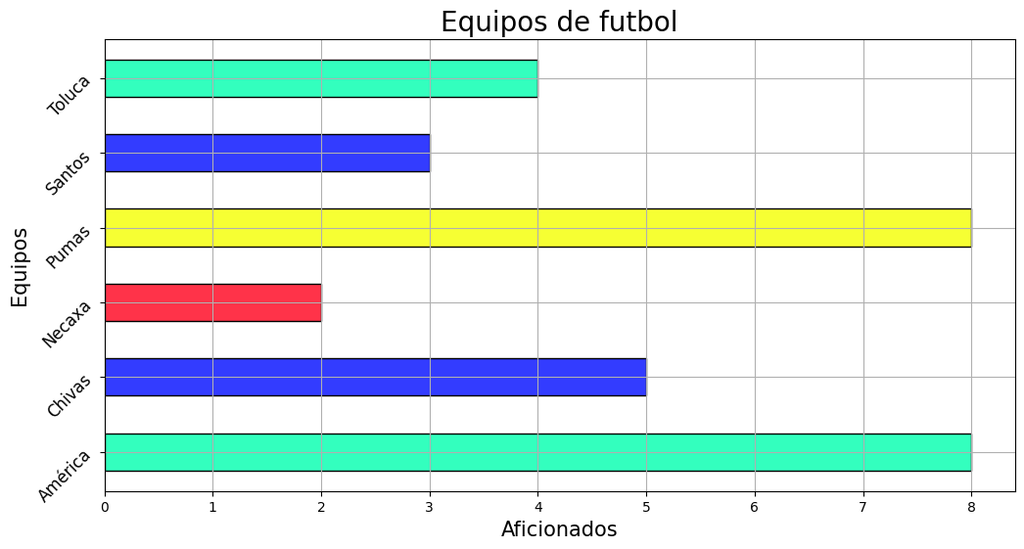

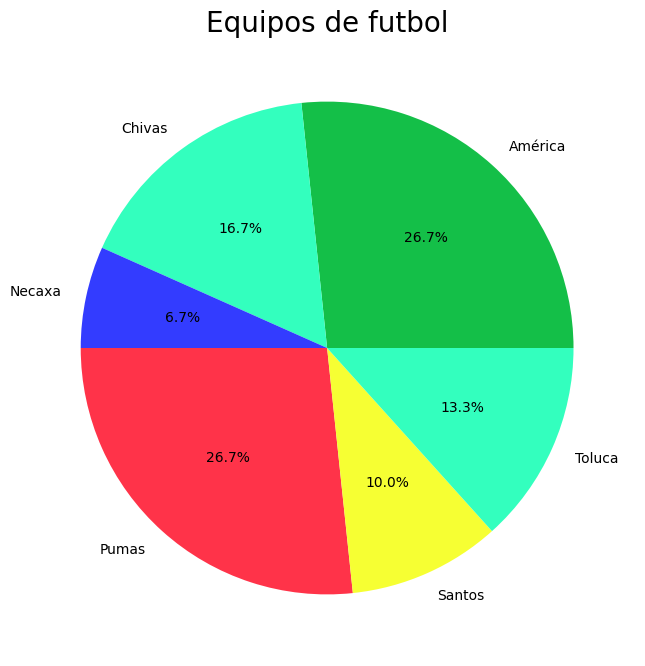

```python
titulo = "Equipos de futbol"
labelx = "Aficionados"
labely = "Equipos"

barras = plot_barras(clases_sorted,fa_sorted, labelx, labely, titulo)
pastel = plot_pie(fr_relativa,clases_sorted,titulo)
```

## Ejercicio 8

Se preguntó a 30 jóvenes cuántas horas dedicaban cada día a navegar en internet (el tiempo que dedican a sesiones de chat y a las redes sociales quedan incluidos). Los resultados son los siguientes:

2.5 4.5 5.8 2.2 5.7 5.3 4.0 0.9 2.5 2.3 3.2 4.9 2.7 3.7 3.8 4.9 2.8 3.6 4.2 3.1 7.2 1.9 5.9 3.3 2.9 1.1 1.7 2.6 3.1 4.4

```python
numeros = [2.5, 4.5, 5.8, 2.2, 5.7, 5.3, 4.0, 0.9, 2.5, 2.3, 3.2, 4.9, 2.7, 3.7, 3.8, 4.9, 2.8, 3.6, 4.2, 3.1, 7.2, 1.9, 5.9, 3.3,
           2.9, 1.1, 1.7, 2.6, 3.1, 4.4]

ordenar = ordenar_asc(numeros)
lim_inf, lim_sup, Mclases = clases_grouped1(numeros)
fa, clases = fa_grouped(ordenar, lim_inf, lim_sup)
frel = obtener_fr(fa)
facum = obtener_fa(frel)
print("Los datos que se representan son numéricos continuos")
```

```
Los datos que se representan son numéricos continuos
```

```python
tbl = tabla_grouped(lim_inf, lim_sup, Mclases, fa, frel, facum)
print(tbl)
```

```
   Limite inferior  Limite superior  Marcas de clase  Frecuencia absoluta  \
0             0.90             2.16             1.53                    4
1             2.16             3.42             2.79                   12
2             3.42             4.68             4.05                    7
3             4.68             5.94             5.31                    6
4             5.94             7.20             6.57                    1

   Frecuencia Relativa  Frecuencia Acumulada
0            13.333333             13.333333
1            40.000000             53.333333
2            23.333333             76.666667
3            20.000000             96.666667
4             3.333333            100.000000
```

## Ejercicio 12

El número de calorías correspondiente a los alimentos tipo sándwich que se sirven en un negocio de comida rápida se presenta a continuación:

250 790 470 510 500 330 300 750 580 740 420 260 440 770 400 540 530 330 390 380 340 460 530 260 410 360 270 510 630 330

a. Realiza un histograma usando seis clases. Describe la forma de la distribución de los datos.  
b. Traza una ojiva y expón tus conclusiones.

```python
datos = [250, 790, 470, 510, 500, 330, 300, 750, 580, 740, 420, 260, 440, 770, 400, 540, 530, 330, 390, 380, 340, 460, 530, 260, 410, 360, 270, 510, 630, 330]

ordenar = ordenar_asc(datos)
lim_inf, lim_sup, Mclases = clases_grouped(datos)
fa, clases = fa_grouped(ordenar, lim_inf, lim_sup)
frel = obtener_fr(fa)
facum = obtener_fa(frel)
```

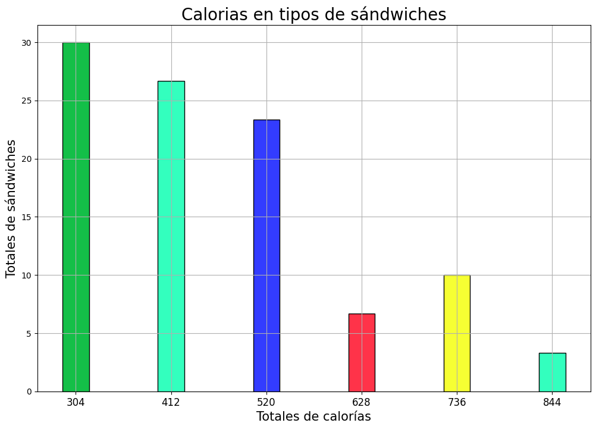

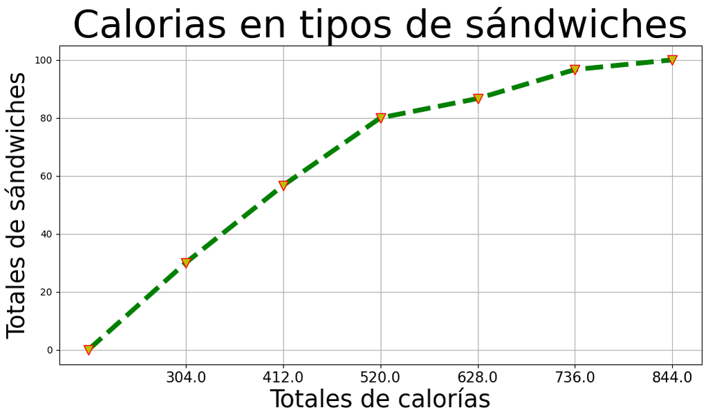

```python
titulo = "Calorias en tipos de sándwiches"
labelx = "Totales de calorías"
labely = "Totales de sándwiches"

histograma = plot_hist(clases, frel, Mclases, labelx, labely, titulo)
ojiva = plot_ojiva(clases, facum, Mclases, labelx, labely, titulo)
```

## Ejercicio 15

En un estudio se desea conocer cuáles son los apellidos más comunes en México.Para ello se les preguntó a 100 personas su apellido y los resultados son los siguientes:

a) Construye una tabla de frecuencias.  
b) ¿Qué tipo de gráficas utilizarías para representar esta información? ¿Por qué?

```python
apellidos = [
"Ramirez",
"Garcia",
"Gonzalez",
"Rodriguez",
"Perez",
"Martinez",
"Garcia",
"Lopez",
"Gutierrez",
"Lopez",
"Rodriguez",
"Martinez",
"Rodriguez",
"Hernandez",
"Garcia",
"Garcia",
"Gonzalez",
"Hernandez",
"Garcia",
"Gutierrez",
"Hernandez",
"Lopez",
"Perez",
"Gonzalez",
"Martinez",
"Ramirez",
"Garcia",
"Rodriguez",
"Hernandez",
"Sanchez",
"Hernandez",
"Gonzalez",
"Rodriguez",
"Sanchez",
"Hernandez",
"Gonzalez",
"Gutierrez",
"Martinez",
"Gonzalez",
"Rodriguez",
"Rodriguez",
"Martinez",
"Ramirez",
"Perez",
"Sanchez",
"Hernandez",
"Hernandez",
"Gonzalez",
"Garcia",
"Hernandez",
"Rodriguez",
"Lopez",
"Sanchez",
"Rodriguez",
"Ramirez",
"Lopez",
"Martinez",
"Garcia",
"Garcia",
"Hernandez",
"Gonzalez",
"Lopez",
"Martinez",
"Lopez",
"Garcia",
"Sanchez",
"Garcia",
"Hernandez",
"Flores",
"Perez",
"Gonzalez",
"Gonzalez",
"Lopez",
"Martinez",
"Gonzalez",
"Martinez",
"Hernandez",
"Ramirez",
"Lopez",
"Sanchez",
"Ramirez",
"Gutierrez",
"Sanchez",
"Flores",
"Garcia",
"Martinez",
"Garcia",
"Flores",
"Perez",
"Lopez",
"Hernandez",
"Martinez",
"Garcia",
"Hernandez",
"Flores",
"Perez",
"Gonzalez",
"Hernandez",
"Sanchez",
"Martinez"
]

datosF = format_list(apellidos)
clases, fa_absoluta = frec_abs(datosF)
clases_sorted = clases_str_sort(clases) #Ordena las clases por ordes alfabetico
fa_sorted = sort_clases_fa(clases, clases_sorted, fa_absoluta) #Ordena las F_absolutas
fr_relativa = frecuencia_rel(fa_sorted) #Calculas las F_relativas
fr_acum = calcular_frecuencia_a(fr_relativa) #Calculas las F_acomuladas
tabla = imptabla(clases_sorted, fa_sorted, fr_relativa, fr_acum) #Ordena los datos recabados en una tabla
print(tabla)
```

```
       Clases  F absoluta  F relativa  F acumulada
0      FLORES           4         4.0          4.0
1      GARCIA          14        14.0         18.0
2    GONZALEZ          12        12.0         30.0
3   GUTIERREZ           4         4.0         34.0
4   HERNANDEZ          15        15.0         49.0
5       LOPEZ          10        10.0         59.0
6    MARTINEZ          12        12.0         71.0
7       PEREZ           6         6.0         77.0
8     RAMIREZ           6         6.0         83.0
9   RODRIGUEZ           9         9.0         92.0
10    SANCHEZ           8         8.0        100.0
```

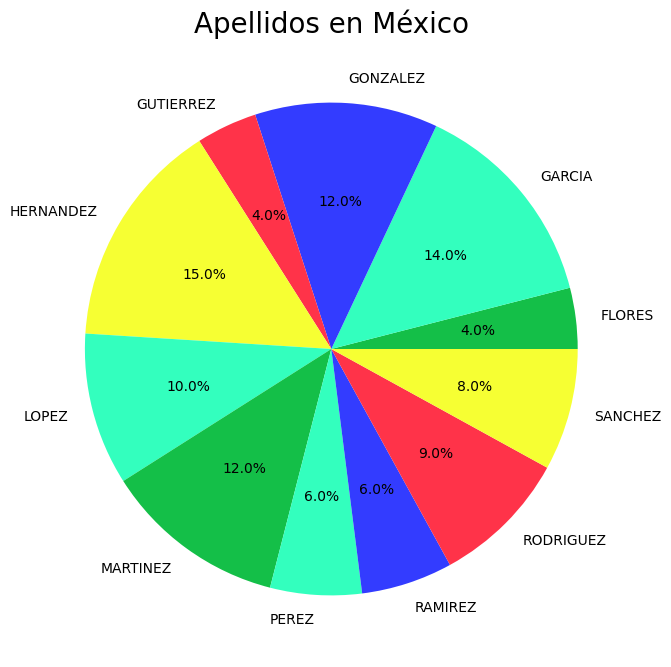

```
se uso el diagrama de pastel ya que representa mejor una vista de los porcentajes en base a los apellidos
```

```python
titulo = "Apellidos en México"
pastel = plot_pie(fr_relativa,clases_sorted,titulo)
print("se uso el diagrama de pastel ya que representa mejor una vista de los porcentajes en base a los apellidos")
```

Volver al inicio